# Analisis de las Horas de sueno de los estudiantes de Utec

## Introducción

### Tema seleccionanado:

1. Estudio de la cantidad de horas de sueño en estudiantes de UTEC en pandemia y factores que afectan en su tiempo de sueño.
1. **¿Es el estudio de interés para la audiencia?** El estudio está relacionado con la salud física y mental de los universitarios de UTEC después de la implementación del modo virtual a las clases causada por la pandemia del Covid-19, estos temas son de alta relevancia para la audiencia seleccionada.
2. **¿Qué información se desea aportar al final del estudio?** Promedio de la cantidad de horas de sueño de un universitario en modo virtual así cómo los posibles efectos o cambios que ocasionan en su vida personal y académica. Comparar estos resultados con estándares adecuados de horas de sueño (en base a la edad).
3. **¿Es posible llegar a la información que se propone de manera específica y concreta?** Sí, mediante una encuesta para recabar información que nos gustaría conocer de los estudiantes de UTEC que será difundida por medio del correo institucional.

## Programación de actividades

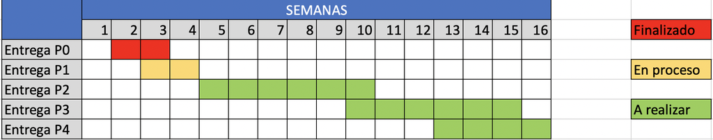

## Objetivos:

#### Principal

- Analizar los horarios de sueño de alumnos de UTEC y ver los diferente factores que pueden influenciar las horas de sueños asi como probables problemas a la salud o de índole académico.

#### Específicos

- Identificar las horas a la semana se dedican a dormir un estudiante de utec en dias regulares, fines de semana y épocas de exámenes.
- Analizar si las horas de sueño pueden tener impacto en la vida personal y académica de los estudiantes de UTEC.
- Analizar y identificar que habitos puedan afectar las horas de sueño.

## Introducción /importancia y justificación

Este trabajo realizará un estudio/análisis completo sobre la cantidad de horas de sueño en los estudiantes de UTEC, nuestro público objetivo, y el impacto que puede tener en la vida personal y académica de estos. Es de suma importancia efectuar este estudio ya que se ve relacionado la salud física y mental del alumno de UTEC, temas delicados e importantes ya que tras la coyuntura política y del COVID-19 la salud mental se vio más deteriorada. Todo esto se justifica a través de datos obtenidos por una encuesta realizada por nuestro equipo la cual nos permitirá obtener variables e información suficiente para responder las preguntas planteadas en el objetivo.

## Marco teórico

Nuestro estudio sera realizara mediante encuesta. Por ello armamos una encuesta con las preguntas que podría necesitar nuestra investigación. Y las repartimos por diversos medios en donde este nuestro publico objetivo los estudiantes de utec.

#### Muestra

- Estudiantes de todas las carreras de UTEC

#### Unidad muestral

- Estudiante de UTEC

#### Tipo de Muestreo

- **Muestreo aleatorio simple**: tomaremos estudiantes al azar de todas las carreras de UTEC

## Variables con su clasificación

| **Pregunta** | **Variable** | **Tipo de variable** | **Restricciones** |
| --- | --- | --- | --- |
| *Ingrese su Código de estudiante UTEC* | Código de estudiante | Numérica discreta | Número de al menos 9 cifras |
| *Ingrese su Carrera* | Carrera | Categórica nominal | Carrera disponible en UTEC |
| *Ingrese su Ciclo actual* | Ciclo | Numérica discreta | Entero positivo menor a 15 |
| *Ingrese su Edad* | Edad | Numérica discreta | Entero positivo |
| *Ingrese su Sexo* | Sexo | Categórica nominal | Masculino, Femenino, Otro |
| *¿Cuántas horas duerme por día de Lunes a Viernes? (En horas)* | Horas de sueño (Lunes a Viernes) | Numérica continua | Entero positivo |
| *¿Cuántas horas duerme por día los fines de semana? (En horas)* | Horas de sueño (Fin de semana) | Numérica continua | Entero positivo |
| *¿Cuántas horas duerme por día en semana de exámenes? (En horas)* | Horas de sueño (Semana de exámenes) | Numérica continua | Entero positivo |
| *¿Tiene dificultad para conciliar el sueño en la noche? (ej: me demoro cómo 30 minutos para dormir)* | Dificultad para dormir | Categórica ordinal | Nada,Poco,Regular,Bastante |
| *¿Suelo despertar a mitad de la noche?* | Se despierta de noche | Categórica ordinal | Nada,Poco,Regular,Bastante |
| *¿No se siente bien descansado después del sueño nocturno?* | No se sentirse bien descansado | Categórica ordinal | Nada,Poco,Regular,Bastante |
| *¿Se despierta muy temprano?* | Despertarse muy temprano | Categórica ordinal | Nada,Poco,Regular,Bastante |
| *¿Tiene preocupaciones constantes respecto del sueño? (Te preocupas por dormir poco)* | Preocupaciones respecto al sueño | Categórica ordinal | Nada,Poco,Regular,Bastante |
| *¿Cuántas horas a la semana le dedicas a actividades extracurriculares?* | Horas de actividades extracurriculares | Numérica continua | Entero positivo |
| *¿En qué momento del día regularmente realizas tus actividades extracurriculares?* | Momento del día que realiza actividades extracurriculares | Categórica nominal | Mañana, Tarde, Noche, No realizo |
| *¿Suele consumir bebidas con cafeína en la noche? (como café,gaseosa,etc)* | Consumo de bebidas con cafeína | Categórica ordinal | Nada,Poco,Regular,Bastante |
| *¿Suele tomar siestas durante el día?* | Siestas durante el día | Categórica ordinal | Nada,Poco,Regular,Bastante |
| *¿Suele pasar mucho tiempo frente a una pantalla por las noches? (celular,laptop,etc)* | Tiempo frente a una pantalla | Categórica ordinal | Nada,Poco,Regular,Bastante |
| *Ingrese la hora en que se acuesta regularmente* | Hora de dormir | Numérica continua | Entero positivo |
| *Ingrese la hora en que se despierta regularmente* | Hora de despertarse | Numérica continua | Entero positivo |
| *Ingrese su promedio del ciclo Pasado* | Promedio | Numérica continua | Número real mayor igual a 0 |
| *¿Qué descripción califica mejor tus horarios de sueño?* | Descripción de horario de sueño | Categórica nominal | Lo respeto bastante, Suelo respetarlo, No suelo respetarlo |